# Optimization

Applied Machine Learning with R [www.therbootcamp.com](https://therbootcamp.github.io) [@therbootcamp](https://twitter.com/therbootcamp)

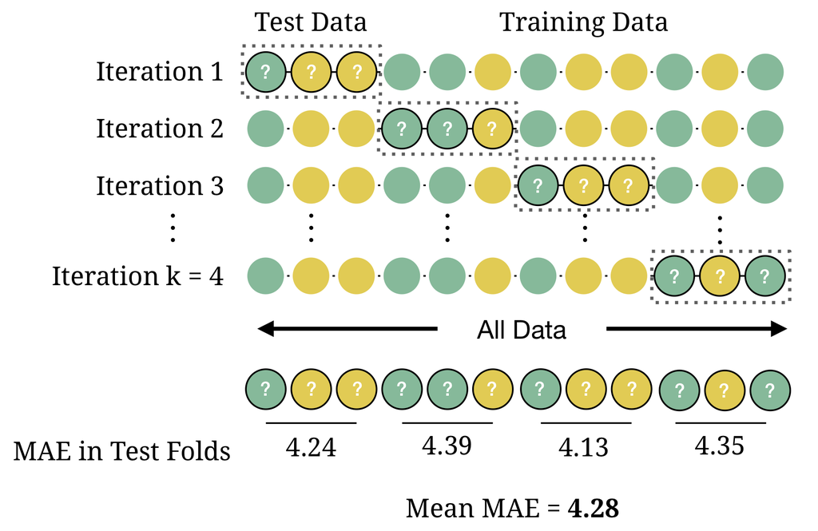

### Overview

By the end of this practical you will know how to:

1. Use cross-validation to select optimal model tuning parameters for decision trees and random forests
2. Compare ‘standard’ regression with lasso and ridge penalised regression
3. Use cross-validation to estimate future test accuracy

### Datasets

| File | Rows | Columns |
| --- | --- | --- |
| hitters_train.csv | 50 | 20 |
| hitters_test.csv | 213 | 20 |
| college_train.csv | 500 | 18 |
| [college_test.csv](https://raw.githubusercontent.com/therbootcamp/appliedML_2019Jan/master/1_Data/college_est.csv) | 277 | 18 |
| house_train.csv | 5000 | 21 |
| house_test.csv | 1000 | 21 |

- The `hitters_train` and `hitters_test` data are taken from the `Hitters` dataset in the `ISLR` package. To see column descriptions, run the following:

```r
library(ISLR)   # Load ISLR package
?Hitters        # Look at help menu for Hitters
```

- The `college_train` and `college_test` data are taken from the `College` dataset in the `ISLR` package. To see column descriptions, run the following:

```r
library(ISLR)   # Load ISLR package
?College        # Look at help menu for College
```

- The `hitters_train` and `hitters_test` data are taken from the `hitters` dataset in the `ISLR` package. To see column descriptions, run the following:

```r
library(ISLR)   # Load ISLR package
?hitters        # Look at help menu for hitters
```

- The `house_train` and `house_test` data come from https://www.kaggle.com/harlfoxem/housesalesprediction

### Glossary

| Function | Package | Description |
| --- | --- | --- |
| `trainControl()` | `caret` | Define modelling control parameters |
| `train()` | `caret` | Train a model |
| `predict(object, newdata)` | `stats` | Predict the criterion values of `newdata` based on `object` |
| `postResample()` | `caret` | Calculate aggregate model performance in regression tasks |
| `confusionMatrix()` | `caret` | Calculate aggregate model performance in classification tasks |

### Packages

| Package | Installation |
| --- | --- |
| `tidyverse` | `install.packages("tidyverse")` |
| `caret` | `install.packages("caret")` |
| `partykit` | `install.packages("partykit")` |
| `party` | `install.packages("party")` |

### Cheatsheet

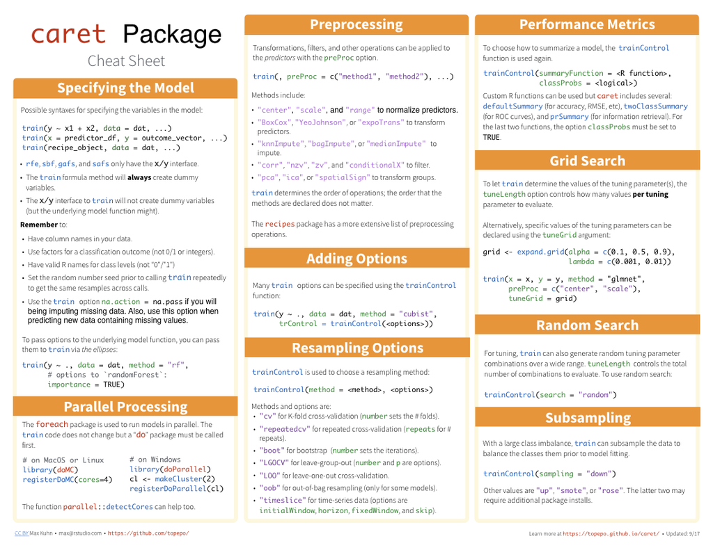

hhttps://github.com/rstudio/cheatsheets/raw/master/caret.pdf

### Examples

```r
# Model optimization with Regression

# Step 0: Load packages-----------

library(tidyverse)    # Load tidyverse for dplyr and tidyr
library(caret)        # For ML mastery
library(partykit)     # For decision trees
library(party)        # For decision trees

# Step 1: Load, clean, and explore data ----------------------

# training data
data_train <- read_csv("1_Data/diamonds_train.csv")

# test data
data_test <- read_csv("1_Data/diamonds_test.csv")

# Convert all characters to factor
#  Some ML models require factors

data_train <- data_train %>%
  mutate_if(is.character, factor)

data_test <- data_test %>%
  mutate_if(is.character, factor)

# Explore training data

data_train        # Print the dataset
View(data_train)  # Open in a new spreadsheet-like window
dim(data_train)   # Print dimensions
names(data_train) # Print the names

# Define criterion_train
#   We'll use this later to evaluate model accuracy

criterion_train <- data_train$price
criterion_test <- data_test$price

# Step 2: Define training control parameters -------------

# Use 10-fold cross validation

ctrl_cv <- trainControl(method = "cv",
                        number = 10)

# Step 3: Train models: -----------------------------
#   Criterion: hwy
#   Features: year, cyl, displ

# Normal Regression --------------------------

price_glm <- train(form = price ~ carat + depth + table + x + y,
                   data = data_train,
                   method = "glm",
                   trControl = ctrl_cv)


# Print key results
price_glm

# RMSE  Rsquared  MAE
# 1506  0.86      921

# Coefficients
coef(price_glm$finalModel)

# (Intercept)       carat       depth       table           x           y
#     21464.9     11040.4      -215.6       -94.2     -3681.6      2358.9

# Lasso --------------------------

# Vector of lambda values to try
lambda_vec <- 10 ^ seq(-3, 3, length = 100)

price_lasso <- train(form = price ~ carat + depth + table + x + y,
                   data = data_train,
                   method = "glmnet",
                   trControl = ctrl_cv,
                   preProcess = c("center", "scale"),  # Standardise
                   tuneGrid = expand.grid(alpha = 1,  # Lasso
                                          lambda = lambda_vec))


# Print key results
price_lasso

# glmnet
#
# 5000 samples
#    5 predictor
#
# Pre-processing: centered (5), scaled (5)
# Resampling: Cross-Validated (10 fold)
# Summary of sample sizes: 4500, 4500, 4500, 4500, 4500, 4500, ...
# Resampling results across tuning parameters:
#
#   lambda    RMSE  Rsquared  MAE
#   1.00e-03  1509  0.858      918
#   1.15e-03  1509  0.858      918
#   1.32e-03  1509  0.858      918
#   1.52e-03  1509  0.858      918

# Plot regularisation parameter versus error
plot(price_lasso)

# Print best regularisation parameter
price_lasso$bestTune$lambda

# Get coefficients from best lambda value

coef(price_lasso$finalModel,
     price_lasso$bestTune$lambda)

# 6 x 1 sparse Matrix of class "dgCMatrix"
#                 1
# (Intercept)  4001
# carat        5179
# depth        -300
# table        -213
# x           -3222
# y            1755


# Ridge --------------------------

# Vector of lambda values to try
lambda_vec <- 10 ^ seq(-3, 3, length = 100)

price_ridge <- train(form = price ~ carat + depth + table + x + y,
                     data = data_train,
                     method = "glmnet",
                     trControl = ctrl_cv,
                     preProcess = c("center", "scale"),  # Standardise
                     tuneGrid = expand.grid(alpha = 0,  # Ridge penalty
                                            lambda = lambda_vec))

# Print key results
price_ridge

# glmnet
#
# 5000 samples
#    5 predictor
#
# Pre-processing: centered (5), scaled (5)
# Resampling: Cross-Validated (10 fold)
# Summary of sample sizes: 4500, 4500, 4500, 4500, 4500, 4500, ...
# Resampling results across tuning parameters:
#
#   lambda    RMSE  Rsquared  MAE
#   1.00e-03  1638  0.835     1137
#   1.15e-03  1638  0.835     1137
#   1.32e-03  1638  0.835     1137
#   1.52e-03  1638  0.835     1137
#   1.75e-03  1638  0.835     1137

# Plot regularisation parameter versus error
plot(price_ridge)

# Print best regularisation parameter
price_ridge$bestTune$lambda

# Get coefficients from best lambda value
coef(price_ridge$finalModel,
     price_ridge$bestTune$lambda)

# 6 x 1 sparse Matrix of class "dgCMatrix"
#                1
# (Intercept) 4001
# carat       2059
# depth       -131
# table       -168
# x            716
# y            797

# Decision Trees --------------------------

# Vector of cp values to try
cp_vec <- seq(0, .1, length = 100)

price_rpart <- train(form = price ~ carat + depth + table + x + y,
                  data = data_train,
                  method = "rpart",
                  trControl = ctrl_cv,
                  tuneGrid = expand.grid(cp = cp_vec))

# Print key results
price_rpart

# Plot complexity parameter vs. error
plot(price_rpart)

# Print best complexity parameter
price_rpart$bestTune$cp

# [1] 0.00202

# Step 3: Estimate prediction accuracy from folds ----

# Get accuracy statistics across folds
resamples_price <- resamples(list(ridge = price_ridge,
                                  lasso = price_lasso,
                                  glm = price_glm))

# Print summary of accuracies
summary(resamples_price)

# MAE
#       Min. 1st Qu. Median Mean 3rd Qu. Max. NA's
# ridge 1094    1100   1117 1137    1170 1217    0
# lasso  869     887    929  918     944  960    0
# glm    856     882    921  920     949  986    0
#
# RMSE
#       Min. 1st Qu. Median Mean 3rd Qu. Max. NA's
# ridge 1545    1580   1609 1638    1703 1772    0
# lasso 1323    1479   1518 1509    1583 1593    0
# glm   1350    1429   1526 1509    1582 1702    0
#
# Rsquared
#        Min. 1st Qu. Median  Mean 3rd Qu.  Max. NA's
# ridge 0.798   0.828  0.836 0.835   0.848 0.854    0
# lasso 0.827   0.846  0.858 0.858   0.868 0.902    0
# glm   0.819   0.849  0.863 0.860   0.870 0.888    0

# Step 4: Measure prediction Accuracy -------------------

# GLM ================================

# Predictions
glm_pred <- predict(price_glm,
                    newdata = data_test)

# Calculate aggregate accuracy
postResample(pred = glm_pred,
             obs = criterion_test)

#     RMSE Rsquared      MAE
# 1654.017    0.832  944.854

# Ridge ================================

# Predictions
ridge_pred <- predict(price_ridge,
                      newdata = data_test)

# Calculate aggregate accuracy
postResample(pred = ridge_pred,
             obs = criterion_test)

#     RMSE Rsquared      MAE
# 1650.541    0.832 1133.063


# Lasso ================================

# Predictions
lasso_pred <- predict(price_lasso,
                      newdata = data_test)

# Calculate aggregate accuracy
postResample(pred = lasso_pred,
             obs = criterion_test)

#     RMSE Rsquared      MAE
# 1653.675    0.832  942.870


# Visualise Accuracy -------------------------

# Tidy competition results
accuracy <- tibble(criterion_test = criterion_test,
                   Regression = glm_pred,
                   Ridge = ridge_pred,
                   Lasso = lasso_pred) %>%
               gather(model, prediction, -criterion_test) %>%

  # Add error measures
  mutate(se = prediction - criterion_test,
         ae = abs(prediction - criterion_test))

# Calculate summaries
accuracy_agg <- accuracy %>%
                  group_by(model) %>%
                  summarise(mae = mean(ae))   # Calculate MAE (mean absolute error)

# Plot A) Scatterplot of truth versus predictions

ggplot(data = accuracy,
       aes(x = criterion_test, y = prediction, col = model)) +
  geom_point(alpha = .5) +
  geom_abline(slope = 1, intercept = 0) +
  labs(x = "True Prices",
       y = "Predicted Prices",
       title = "Predicting Diamond Prices",
       subtitle = "Black line indicates perfect performance")

# Plot B) Violin plot of absolute errors

ggplot(data = accuracy,
       aes(x = model, y = ae, fill = model)) +
  geom_violin() +
  geom_jitter(width = .05, alpha = .2) +
  labs(title = "Fitting Absolute Errors",
       subtitle = "Numbers indicate means",
       x = "Model",
       y = "Absolute Error (Log Transformed)") +
  guides(fill = FALSE) +
  annotate(geom = "label",
           x = accuracy_agg$model,
           y = accuracy_agg$mae,
           label = round(accuracy_agg$mae, 2)) +
  scale_y_continuous(trans='log')
```

# Baseball player salaries

In this practical, we will predict the salaries of baseball players from the `hitters_train` and `hitters_test` datasets. Here’s how the first few rows of `hitters_train` should look:

| Salary | AtBat | Hits | HmRun | Runs | RBI | Walks | Years | CAtBat | CHits | CHmRun | CRuns | CRBI | CWalks | League | Division | PutOuts | Assists | Errors | NewLeague |
| --- | --- | --- | --- | --- | --- | --- | --- | --- | --- | --- | --- | --- | --- | --- | --- | --- | --- | --- | --- |
| 70 | 215 | 51 | 4 | 19 | 18 | 11 | 1 | 215 | 51 | 4 | 19 | 18 | 11 | A | E | 116 | 5 | 12 | A |
| 475 | 458 | 114 | 13 | 67 | 57 | 48 | 4 | 1350 | 298 | 28 | 160 | 123 | 122 | A | W | 246 | 389 | 18 | A |
| 1043 | 586 | 159 | 12 | 72 | 79 | 53 | 9 | 3082 | 880 | 83 | 363 | 477 | 295 | N | E | 181 | 13 | 4 | N |
| 775 | 568 | 158 | 20 | 89 | 75 | 73 | 15 | 8068 | 2273 | 177 | 1045 | 993 | 732 | N | W | 105 | 290 | 10 | N |
| 80 | 399 | 102 | 3 | 56 | 34 | 34 | 5 | 670 | 167 | 4 | 89 | 48 | 54 | A | W | 211 | 9 | 3 | A |
| 657 | 579 | 174 | 7 | 67 | 78 | 58 | 6 | 3053 | 880 | 32 | 366 | 337 | 218 | N | E | 280 | 479 | 5 | N |
| 875 | 496 | 119 | 8 | 57 | 33 | 21 | 7 | 3358 | 882 | 36 | 365 | 280 | 165 | N | W | 155 | 371 | 29 | N |
| 738 | 510 | 126 | 2 | 42 | 44 | 35 | 11 | 5562 | 1578 | 44 | 703 | 519 | 256 | N | W | 207 | 358 | 20 | N |
| 1800 | 551 | 171 | 13 | 94 | 83 | 94 | 13 | 6090 | 1840 | 128 | 969 | 900 | 917 | N | E | 1199 | 149 | 5 | N |
| 417 | 313 | 78 | 6 | 32 | 41 | 12 | 12 | 3742 | 968 | 35 | 409 | 321 | 170 | N | W | 106 | 206 | 7 | N |

Our goal will be to predict `Salary`.

## A - Setup

1. Open your `BaselRBootcamp` R project. It should already have the folders `1_Data` and `2_Code`. Make sure that the data file(s) listed in the `Datasets` section above are in your `1_Data` folder
2. Open a new R script. At the top of the script, using comments, write your name and the date. Save it as a new file called `Optimization_practical.R` in the `2_Code` folder.
3. Using `library()` load the set of packages for this practical listed in the packages section above.

```r
## NAME
## DATE
## Optimization Practical - With regression, decision trees, and random forests

library(tidyverse)
library(caret)
library(party)
library(partykit)
```

4. Run the code below to load each of the datasets listed in the `Datasets` as new objects

```r
# hitters data
hitters_train <- read_csv(file = "1_Data/hitters_train.csv")
hitters_test <- read_csv(file = "1_Data/hitters_test.csv")
```

5. Take a look at the first few rows of each dataframe by printing them to the console.

```r
# Print dataframes to the console

hitters_train
hitters_test
```

6. Print the numbers of rows and columns of each dataset using the `dim()` function

```r
# Print numbers of rows and columns

dim(XXX)
dim(XXX)
```

```r
dim(hitters_train)
```

```
[1] 50 20
```

```r
dim(hitters_test)
```

```
[1] 213  20
```

7. Look at the names of the dataframes with the `names()` function.

```r
# Print the names of each dataframe

names(XXX)
names(XXX)
```

```r
names(hitters_train)
```

```
 [1] "Salary"    "AtBat"     "Hits"      "HmRun"     "Runs"
 [6] "RBI"       "Walks"     "Years"     "CAtBat"    "CHits"
[11] "CHmRun"    "CRuns"     "CRBI"      "CWalks"    "League"
[16] "Division"  "PutOuts"   "Assists"   "Errors"    "NewLeague"
```

```r
names(hitters_test)
```

```
 [1] "Salary"    "AtBat"     "Hits"      "HmRun"     "Runs"
 [6] "RBI"       "Walks"     "Years"     "CAtBat"    "CHits"
[11] "CHmRun"    "CRuns"     "CRBI"      "CWalks"    "League"
[16] "Division"  "PutOuts"   "Assists"   "Errors"    "NewLeague"
```

8. Open each dataset in a new window using `View()`. Do they look ok?

```r
# Open each dataset in a window.

View(XXX)
View(XXX)
```

9. We need to do a little bit of data cleaning before starting. Specifically, we need to convert all character columns to factors: Do this by running the following code:

```r
# Convert all character columns to factor

hitters_train <- hitters_train %>%
          mutate_if(is.character, factor)

hitters_test <- hitters_test %>%
          mutate_if(is.character, factor)
```

## B - Setup `trainControl`

1. Set up your training by specifying `ctrl_cv` as 10-fold cross-validation
- Set method = “cv” to specify cross validation
- Set number = 10 to specify 10 folds

```r
# Use 10-fold cross validation
ctrl_cv <- trainControl(method = "XX",
                        number = XX)
```

```r
# Use 10-fold cross validation
ctrl_cv <- trainControl(method = "cv",
                        number = 10)
```

## C - Regression (standard)

1. Fit a (standard) regression model predicting `Salary` as a function of all features
- Set the formula to `Salary ~ .`
- Set the data to `hitters_train`
- Set the method to `"glm"` for regular regression
- Set the train control argument to `ctrl_cv`

```r
# Normal Regression --------------------------

salary_glm <- train(form = XX ~ .,
                    data = XX,
                    method = "XX",
                    trControl = XX)
```

```r
# Normal Regression --------------------------

salary_glm <- train(form = Salary ~ .,
                   data = hitters_train,
                   method = "glm",
                   trControl = ctrl_cv)
```

3. Print your `salary_glm` what do you see?

```r
salary_glm
```

```
Generalized Linear Model

50 samples
19 predictors

No pre-processing
Resampling: Cross-Validated (10 fold)
Summary of sample sizes: 45, 43, 46, 46, 44, 46, ...
Resampling results:

  RMSE  Rsquared  MAE
  523   0.273     441
```

4. Try plotting your `salary_glm` object. What happens? What does this error mean?

```r
# I get the following error:

# Error in plot.train(salary_glm) :
#   There are no tuning parameters for this model.


# The problem is that method = "glm" has no tuning parameters so there is nothing to plot!
```

5. Print your final model object with `salary_glm$finalModel`

```r
# Print final regression model
salary_glm$finalModel
```

```
Call:  NULL

Coefficients:
(Intercept)        AtBat         Hits        HmRun         Runs
   664.0169      -1.8086      12.7263      14.0206     -10.7594
        RBI        Walks        Years       CAtBat        CHits
    -5.1859      -8.6702     -62.3666       0.4883      -4.9553
     CHmRun        CRuns         CRBI       CWalks      LeagueN
    -8.3973       5.7164       4.3061       0.3754     144.0316
  DivisionW      PutOuts      Assists       Errors   NewLeagueN
   -75.0233      -0.0843       0.5934      -9.7698     223.6980

Degrees of Freedom: 49 Total (i.e. Null);  30 Residual
Null Deviance:      12600000
Residual Deviance: 5110000  AIC: 761
```

6. Print your final regression model coefficients with `coef()`.

```r
# Print glm coefficients
coef(salary_glm$finalModel)
```

```
(Intercept)       AtBat        Hits       HmRun        Runs         RBI
   664.0169     -1.8086     12.7263     14.0206    -10.7594     -5.1859
      Walks       Years      CAtBat       CHits      CHmRun       CRuns
    -8.6702    -62.3666      0.4883     -4.9553     -8.3973      5.7164
       CRBI      CWalks     LeagueN   DivisionW     PutOuts     Assists
     4.3061      0.3754    144.0316    -75.0233     -0.0843      0.5934
     Errors  NewLeagueN
    -9.7698    223.6980
```

## D - Ridge Regression

It’s time to fit an optimized regression model with a Ridge penalty!

```r
# Vector of lambda values to try
lambda_vec <- 10 ^ -(seq(-4, 4, length = 100))
```

2. Fit a ridge regression model predicting `Salary` as a function of all features
- Set the formula to `Salary ~ .`
- Set the data to `hitters_train`
- Set the method to `"glmnet"` for regularized regression
- Set the train control argument to `ctrl_cv`
- Set the `preProcess` argument to `c("center", "scale")` to make sure the variables are standarised when estimating the beta weights (this is good practice for ridge regression)
- Set the tuneGrid argument such that alpha is 0 (for ridge regression), and with all lambda values you specified in `lambda_vec` (we’ve done this for you below)

```r
# Ridge Regression --------------------------

salary_ridge <- train(form = XX ~ .,
                      data = XX,
                      method = "XX",
                      trControl = XX,
                      preProcess = c("XX", "XX"),  # Standardise
                      tuneGrid = expand.grid(alpha = 0,  # Ridge penalty
                                             lambda = lambda_vec))
```

```r
# Ridge Regression --------------------------

salary_ridge <- train(form = Salary ~ .,
                      data = hitters_train,
                      method = "glmnet",
                      trControl = ctrl_cv,
                      preProcess = c("center", "scale"),  # Standardise
                      tuneGrid = expand.grid(alpha = 0,  # Ridge penalty
                                             lambda = lambda_vec))
```

3. Print your `salary_ridge` object what do you see?

```r
salary_ridge
```

```
glmnet

50 samples
19 predictors

Pre-processing: centered (19), scaled (19)
Resampling: Cross-Validated (10 fold)
Summary of sample sizes: 45, 45, 44, 46, 45, 45, ...
Resampling results across tuning parameters:

  lambda    RMSE  Rsquared  MAE
  1.00e-04  454   0.313     340
  1.20e-04  454   0.313     340
  1.45e-04  454   0.313     340
  1.75e-04  454   0.313     340
  2.10e-04  454   0.313     340
  2.54e-04  454   0.313     340
  3.05e-04  454   0.313     340
  3.68e-04  454   0.313     340
  4.43e-04  454   0.313     340
  5.34e-04  454   0.313     340
  6.43e-04  454   0.313     340
  7.74e-04  454   0.313     340
  9.33e-04  454   0.313     340
  1.12e-03  454   0.313     340
  1.35e-03  454   0.313     340
  1.63e-03  454   0.313     340
  1.96e-03  454   0.313     340
  2.36e-03  454   0.313     340
  2.85e-03  454   0.313     340
  3.43e-03  454   0.313     340
  4.13e-03  454   0.313     340
  4.98e-03  454   0.313     340
  5.99e-03  454   0.313     340
  7.22e-03  454   0.313     340
  8.70e-03  454   0.313     340
  1.05e-02  454   0.313     340
  1.26e-02  454   0.313     340
  1.52e-02  454   0.313     340
  1.83e-02  454   0.313     340
```

[output cut: 60 more lines]

```
  1.56e+03  396   0.452     300
  1.87e+03  399   0.461     302
  2.26e+03  401   0.470     304
  2.72e+03  405   0.479     307
  3.27e+03  408   0.487     309
  3.94e+03  412   0.495     313
  4.75e+03  417   0.501     317
  5.72e+03  421   0.507     321
  6.89e+03  426   0.512     325
  8.30e+03  431   0.516     329
  1.00e+04  435   0.520     333

Tuning parameter 'alpha' was held constant at a value of 0
RMSE was used to select the optimal model using the smallest value.
The final values used for the model were alpha = 0 and lambda = 890.
```

4. Plot your `salary_ridge` object. What do you see? Which value of the regularization parameter seems to be the best?

```r
# Plot salary_ridge object
plot(XX)
```

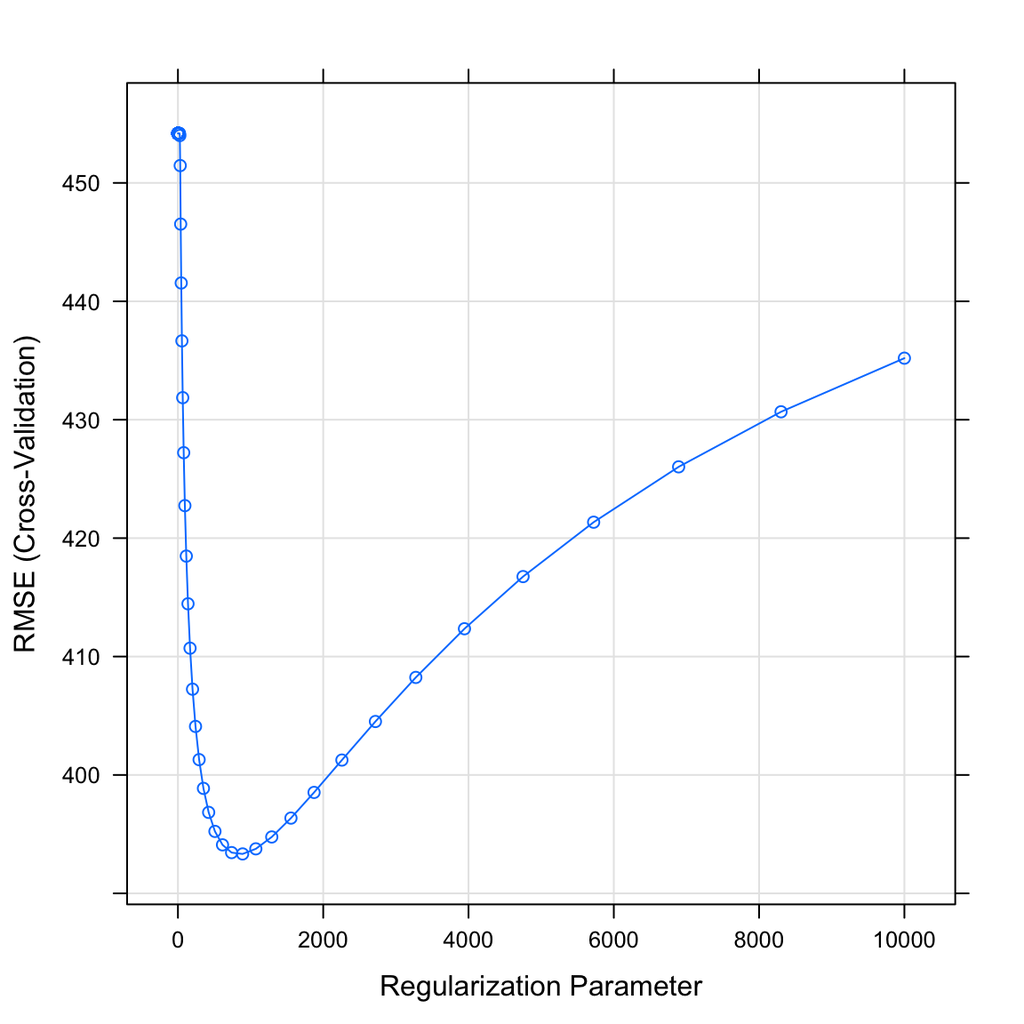

```r
plot(salary_ridge)
```

5. Print the best value of lambda by running the following code. Does this match what you saw in the plot above?

```r
# Print best regularisation parameter
salary_ridge$bestTune$lambda
```

```
[1] 890
```

6. What were your final regression model coefficients for the best lambda value? Find them by running the following code:

```r
# Get coefficients from best lambda value
coef(salary_ridge$finalModel,
     salary_ridge$bestTune$lambda)
```

```
20 x 1 sparse Matrix of class "dgCMatrix"
                 1
(Intercept) 608.79
AtBat        -6.30
Hits          6.78
HmRun        -7.65
Runs          8.16
RBI           6.96
Walks        11.70
Years        13.70
CAtBat       29.45
CHits        31.17
CHmRun       24.79
CRuns        37.78
CRBI         33.51
CWalks       39.65
LeagueN      39.21
DivisionW   -37.83
PutOuts      13.73
Assists      37.15
Errors      -10.95
NewLeagueN   26.18
```

7. How do these coefficients compare to what you found in regular regression? Are they similar? Different?

```r
# Actually the look quite different! The reason why is that we have changed the scale using preProcess

# If you want the coefficients on the original scale, you'd need to convert them, or run your training again without any processing. However, this can lead to problems finding the optimal Lambda value...
```

## E - Lasso Regression

It’s time to fit an optimized regression model with a Lasso penalty!

```r
# Determine possible values of lambda

lambda_vec <- 10 ^ seq(from = -4, to = 4, length = 100)
```

2. Fit a lasso regression model predicting `Salary` as a function of all features
- Set the formula to `Salary ~ .`
- Set the data to `hitters_train`
- Set the method to `"glmnet"` for regularized regression
- Set the train control argument to `ctrl_cv`
- Set the `preProcess` argument to `c("center", "scale")` to make sure the variables are standarised when estimating the beta weights (this is good practice for lasso regression)
- Set the tuneGrid argument such that alpha is 1 (for lasso regression), and with all lambda values you specified in `lambda_vec` (we’ve done this for you below)

```r
# Lasso Regression --------------------------

salary_lasso <- train(form = XX ~ .,
                      data = XX,
                      method = "XX",
                      trControl = XX,
                      preProcess = c("XX", "XX"),  # Standardise
                      tuneGrid = expand.grid(alpha = 1,  # Lasso penalty
                                            lambda = lambda_vec))
```

```r
# Fit a lasso regression

salary_lasso <- train(form = Salary ~ .,
                   data = hitters_train,
                   method = "glmnet",
                   trControl = ctrl_cv,
                   preProcess = c("center", "scale"),
                   tuneGrid = expand.grid(alpha = 1,  # Lasso penalty
                                          lambda = lambda_vec))
```

3. Print your `salary_lasso` object what do you see?

```r
salary_lasso
```

```
glmnet

50 samples
19 predictors

Pre-processing: centered (19), scaled (19)
Resampling: Cross-Validated (10 fold)
Summary of sample sizes: 45, 44, 44, 45, 46, 44, ...
Resampling results across tuning parameters:

  lambda    RMSE  Rsquared  MAE
  1.00e-04  611   0.205     491
  1.20e-04  611   0.205     491
  1.45e-04  611   0.205     491
  1.75e-04  611   0.205     491
  2.10e-04  611   0.205     491
  2.54e-04  611   0.205     491
  3.05e-04  611   0.205     491
  3.68e-04  611   0.205     491
  4.43e-04  611   0.205     491
  5.34e-04  611   0.205     491
  6.43e-04  611   0.205     491
  7.74e-04  611   0.205     491
  9.33e-04  611   0.205     491
  1.12e-03  611   0.205     491
  1.35e-03  611   0.205     491
  1.63e-03  611   0.205     491
  1.96e-03  611   0.205     491
  2.36e-03  611   0.205     491
  2.85e-03  611   0.205     491
  3.43e-03  611   0.205     491
  4.13e-03  611   0.205     491
  4.98e-03  611   0.205     491
  5.99e-03  611   0.205     491
  7.22e-03  611   0.205     491
  8.70e-03  611   0.205     491
  1.05e-02  611   0.205     491
  1.26e-02  611   0.205     491
  1.52e-02  611   0.205     491
  1.83e-02  611   0.205     491
```

[output cut: 60 more lines]

```
  1.56e+03  480     NaN     375
  1.87e+03  480     NaN     375
  2.26e+03  480     NaN     375
  2.72e+03  480     NaN     375
  3.27e+03  480     NaN     375
  3.94e+03  480     NaN     375
  4.75e+03  480     NaN     375
  5.72e+03  480     NaN     375
  6.89e+03  480     NaN     375
  8.30e+03  480     NaN     375
  1.00e+04  480     NaN     375

Tuning parameter 'alpha' was held constant at a value of 1
RMSE was used to select the optimal model using the smallest value.
The final values used for the model were alpha = 1 and lambda = 54.6.
```

4. Plot your `salary_lasso` object. What do you see? Which value of the regularization parameter seems to be the best?

```r
# Plot salary_lasso object
plot(XX)
```

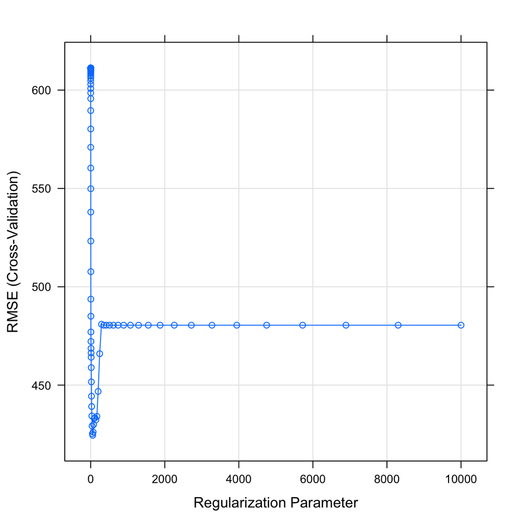

```r
plot(salary_lasso)
```

5. Print the best value of lambda by running the following code. Does this match what you saw in the plot above?

```r
# Print best regularisation parameter
salary_lasso$bestTune$lambda
```

```
[1] 54.6
```

6. What were your final regression model coefficients for the best lambda value? Find them by running the following code:

```r
# Get coefficients from best lambda value
coef(salary_lasso$finalModel,
     salary_lasso$bestTune$lambda)
```

```
20 x 1 sparse Matrix of class "dgCMatrix"
                1
(Intercept) 608.8
AtBat         .
Hits          .
HmRun         .
Runs          .
RBI           .
Walks         .
Years         .
CAtBat        .
CHits         .
CHmRun        .
CRuns       128.1
CRBI          .
CWalks      105.6
LeagueN      80.2
DivisionW   -48.0
PutOuts       .
Assists      29.9
Errors        .
NewLeagueN    .
```

7. How do these coefficients compare to what you found in regular regression? Are they similar? Different? Do you notice that any coefficients are now set to exactly 0?

```r
# Yep!

# I see that many features are now removed!
```

## F - Decision Tree

It’s time to fit an optimized decision tree model!!

1. Before we can fit a decision tree, we need to specify which values of the complexity parameter `cp` we want to try. Using the code below, create a vector called `cp_vec` which contains 100 values between 0 and 1

```r
# Determine possible values of the complexity parameter cp

cp_vec <- seq(from = 0, to = 1, length = 100)
```

2. Fit a decision tree model predicting `Salary` as a function of all features
- Set the formula to `Salary ~ .`
- Set the data to `hitters_train`
- Set the method to `"rpart"` for decision trees
- Set the train control argument to `ctrl_cv`
- Set the tuneGrid argument with all `cp` values you specified in `cp_vec`

```r
# Decision Tree --------------------------

salary_rpart <- train(form = XX ~ .,
                  data = XX,
                  method = "XX",
                  trControl = XX,
                  tuneGrid = expand.grid(cp = cp_vec))
```

```r
# Decision Tree --------------------------

salary_rpart <- train(form = Salary ~ .,
                  data = hitters_train,
                  method = "rpart",
                  trControl = ctrl_cv,
                  tuneGrid = expand.grid(cp = cp_vec))
```

3. Print your `salary_rpart` object what do you see?

```r
salary_rpart
```

```
CART

50 samples
19 predictors

No pre-processing
Resampling: Cross-Validated (10 fold)
Summary of sample sizes: 45, 45, 45, 44, 45, 46, ...
Resampling results across tuning parameters:

  cp      RMSE  Rsquared  MAE
  0.0000  494   0.25380   394
  0.0101  494   0.25380   394
  0.0202  494   0.25380   394
  0.0303  494   0.25380   394
  0.0404  491   0.25264   395
  0.0505  491   0.25264   395
  0.0606  511   0.21445   416
  0.0707  511   0.19485   419
  0.0808  500   0.27169   397
  0.0909  499   0.25986   400
  0.1010  515   0.26111   409
  0.1111  512   0.26111   409
  0.1212  508   0.26001   409
  0.1313  499   0.28888   401
  0.1414  499   0.28888   401
  0.1515  500   0.28888   404
  0.1616  500   0.28888   404
  0.1717  500   0.28888   404
  0.1818  500   0.28888   404
  0.1919  500   0.28888   404
  0.2020  500   0.28888   404
  0.2121  500   0.28888   404
  0.2222  500   0.28888   404
  0.2323  500   0.28888   404
  0.2424  500   0.28888   404
  0.2525  512   0.22942   423
  0.2626  530   0.11363   436
  0.2727  534   0.04042   442
  0.2828  529   0.04583   434
```

[output cut: 59 more lines]

```
  0.8889  478       NaN   378
  0.8990  478       NaN   378
  0.9091  478       NaN   378
  0.9192  478       NaN   378
  0.9293  478       NaN   378
  0.9394  478       NaN   378
  0.9495  478       NaN   378
  0.9596  478       NaN   378
  0.9697  478       NaN   378
  0.9798  478       NaN   378
  0.9899  478       NaN   378
  1.0000  478       NaN   378

RMSE was used to select the optimal model using the smallest value.
The final value used for the model was cp = 1.
```

4. Plot your `salary_rpart` object. What do you see? Which value of the regularization parameter seems to be the best?

```r
# Plot salary_rpart object
plot(XX)
```

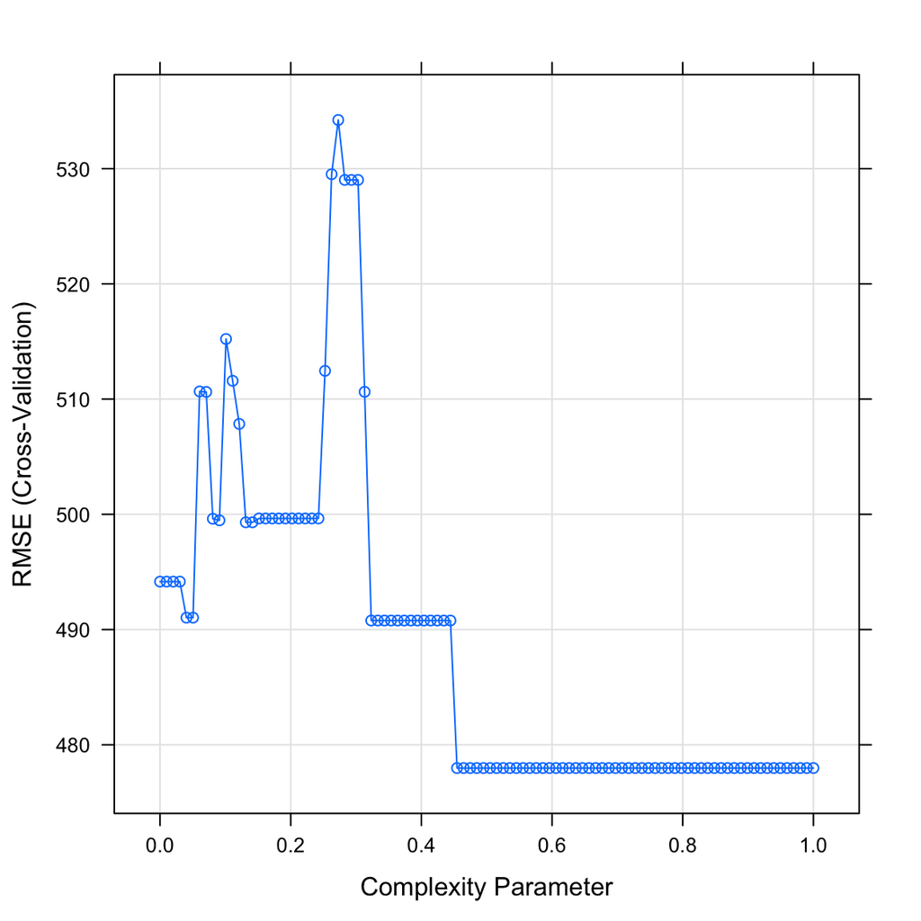

```r
plot(salary_rpart)
```

5. Print the best value of lambda by running the following code. Does this match what you saw in the plot above?

```r
# Print best regularisation parameter
salary_rpart$bestTune$cp
```

```
[1] 1
```

6. Plot your final decision tree using the following code

```r
# Visualise your trees
plot(as.party(salary_rpart$finalModel))
```

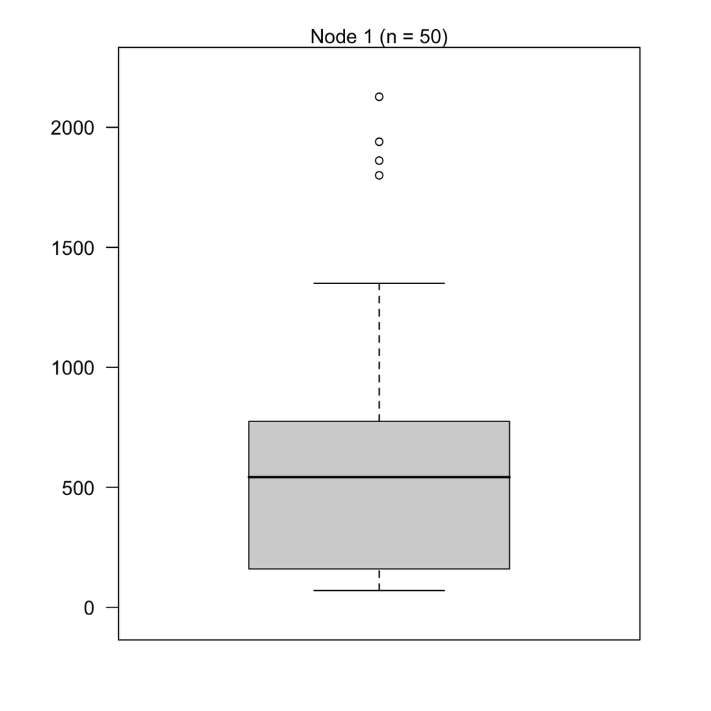

```r
# Visualise your trees
plot(as.party(salary_rpart$finalModel))
```

7. How do the nodes in the tree compare to the coefficients you found in your regression analyses? Do you see similarities or differences?

```r
# Actually, the tree just has one root and no nodes! This is due to the optimal complexity parameter being so high.
```

## G - Random Forests

It’s time to fit an optimized random forest model!

1. Before we can fit a random forest model, we need to specify which values of the diversity parameter `mtry` we want to try. Using the code below, create a vector called `mtry_vec` which is a sequence of numbers from 1 to 10

```r
# Determine possible values of the random forest diversity parameter mtry

mtry_vec <- 1:10
```

2. Fit a random forest model predicting `Salary` as a function of all features
- Set the formula to `Salary ~ .`
- Set the data to `hitters_train`
- Set the method to `"rf"` for random forests
- Set the train control argument to `ctrl_cv`
- Set the tuneGrid argument such that mtry can take on the values you defined in `mtry_vec`

```r
# Random Forest --------------------------

salary_rf <- train(form = XX ~ .,
                   data = XX,
                   method = "XX",
                   trControl = XX,
                   tuneGrid = expand.grid(mtry = mtry_vec))
```

```r
# Random Forest --------------------------

salary_rf <- train(form = Salary ~ .,
                   data = hitters_train,
                   method = "rf",
                   trControl = ctrl_cv,
                   tuneGrid = expand.grid(mtry = mtry_vec))
```

3. Print your `salary_rf` object what do you see?
4. Plot your `salary_rf` object. What do you see? Which value of the regularization parameter seems to be the best?

```r
# Plot salary_rf object
plot(XX)
```

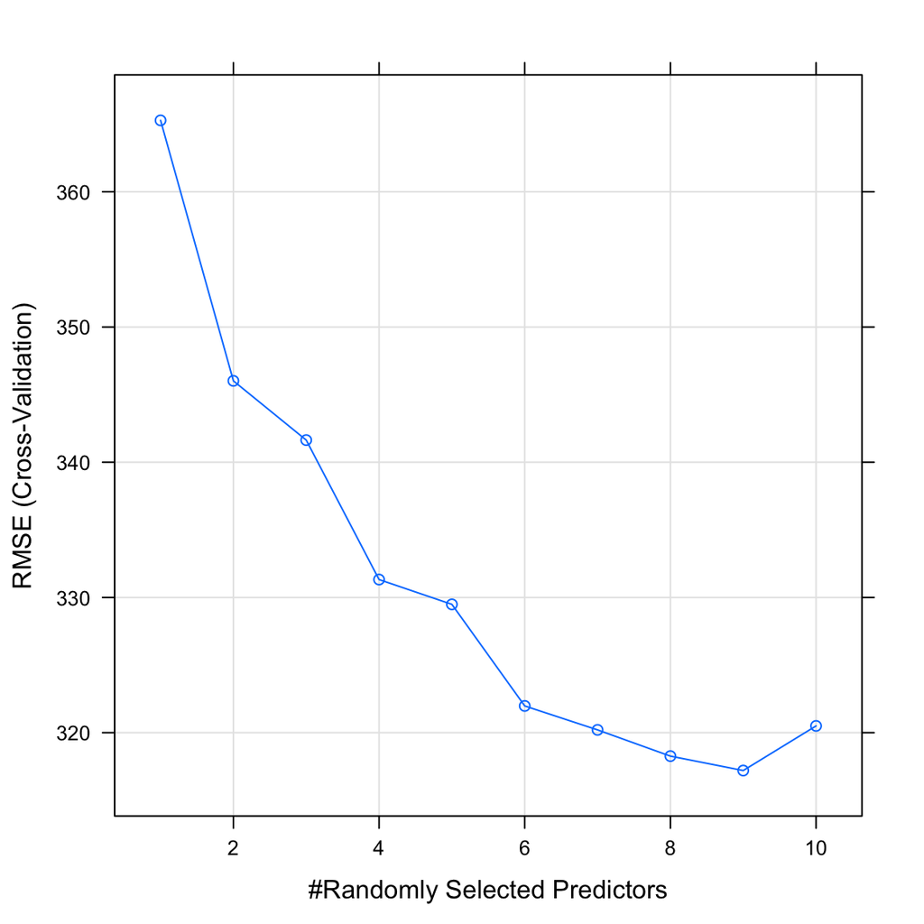

```r
plot(salary_rf)
```

5. Print the best value of mtry by running the following code. Does this match what you saw in the plot above?

```r
# Print best mtry parameter
salary_rf$bestTune$mtry
```

```
[1] 9
```

## H - Estimate prediction accuracy from training folds

1. Using `resamples()`, calculate the estimated prediction accuracy for each of your models. To do this, put your model objects in the named list (e.g.; `glm = salary_glm`, …)

```r
# Summarise accuracy statistics across folds

salary_resamples <- resamples(list(glm = XXX,
                                   ridge = XXX,
                                   lasso = XXX,
                                   dt = XXX,
                                   rf = XXX))
```

```r
# Summarise accuracy statistics across folds

salary_resamples <- resamples(list(glm = salary_glm,
                                   ridge = salary_ridge,
                                   lasso = salary_lasso,
                                   dt = salary_rpart,
                                   rf = salary_rf))
```

2. Look at the summary of your `salary_resamples` object with `summary(salary_resamples)`. What does this tell you? Which model do you expect to have the best prediction accuracy for the test data?

```r
# Print summaries of cross-validation accuracy

# I see below that the random forest model has the lowest mean MAE, so I
#  would expect it to be the best model in the true test data
summary(salary_resamples)
```

```
Call:
summary.resamples(object = salary_resamples)

Models: glm, ridge, lasso, dt, rf
Number of resamples: 10

MAE
       Min. 1st Qu. Median Mean 3rd Qu. Max. NA's
glm   249.1     292    378  441     611  710    0
ridge 132.8     220    267  298     342  578    0
lasso 148.2     263    347  328     370  524    0
dt    191.7     286    373  378     463  544    0
rf     87.6     169    217  223     264  346    0

RMSE
      Min. 1st Qu. Median Mean 3rd Qu. Max. NA's
glm    297     342    467  523     654  914    0
ridge  183     249    325  393     437  907    0
lasso  175     318    401  424     483  885    0
dt     251     342    423  478     665  726    0
rf     112     227    297  317     321  692    0

Rsquared
          Min. 1st Qu. Median  Mean 3rd Qu.  Max. NA's
glm   0.000151 0.00722 0.0733 0.273   0.522 0.771    0
ridge 0.002319 0.10065 0.5269 0.428   0.606 0.991    0
lasso 0.031517 0.27983 0.4492 0.467   0.663 0.906    0
dt          NA      NA     NA   NaN      NA    NA   10
rf    0.271936 0.47366 0.6919 0.656   0.843 0.999    0
```

## I - Calculate prediction accuracy

1. Save the criterion value for the test data as a new vector called `criterion_test`

```r
# Save salaries of players in test dataset as criterion_test
criterion_test <- XXX$XXX
```

```r
criterion_test <- hitters_test$Salary
```

2. Using `predict()`, save the prediction of your regular regression model `salary_glm` for the `hitters_test` data as a new object called `glm_pred`:
- Set the first argument to `salary_glm`
- Set the newdata argument to `hitters_test`

```r
# Save the glm predicted salaries of hitters_test
glm_pred <- predict(XXX, newdata = XXX)
```

```r
# Save predictions for glm
glm_pred <- predict(salary_glm, newdata = hitters_test)
```

3. Now do the same with your ridge, lasso, decision tree, and random forest models to get the objects `ridge_pred`, `lasso_pred`, `rpart_pred` and `rf_pred`

```r
ridge_pred <- predict(XXX, newdata = XXX)
lasso_pred <- predict(XXX, newdata = XXX)
rpart_pred <- predict(XXX, newdata = XXX)
rf_pred <- predict(XXX, newdata = XXX)
```

```r
# Save predictions from other models

ridge_pred <- predict(salary_ridge, newdata = hitters_test)
lasso_pred <- predict(salary_lasso, newdata = hitters_test)
rpart_pred <- predict(salary_rpart, newdata = hitters_test)
rf_pred <- predict(salary_rf, newdata = hitters_test)
```

4. Using `postResample()`, calculate the aggregate prediction accuracy for each model using the template below
- Set the pred argument to your model predictions (e.g.; `ridge_pred`)
- Set the `obs` argument to the true criterion values `criterion_test`)

```r
# Calculate aggregate accuracy for a model
postResample(pred = XXX,
             obs = XXX)
```

```r
# Prediction error for normal regression
postResample(pred = glm_pred,
             obs = hitters_test$Salary)
```

```
    RMSE Rsquared      MAE
552.1782   0.0907 421.8898
```

```r
# Prediction error for ridge regression
postResample(pred = ridge_pred,
             obs = hitters_test$Salary)
```

```
    RMSE Rsquared      MAE
 364.885    0.338  275.275
```

```r
# Prediction error for lasso regression
postResample(pred = lasso_pred,
             obs = hitters_test$Salary)
```

```
    RMSE Rsquared      MAE
 386.992    0.257  286.544
```

```r
# Prediction error for decision trees
postResample(pred = rpart_pred,
             obs = hitters_test$Salary)
```

```
    RMSE Rsquared      MAE
     445       NA      358
```

```r
# Prediction error for random forests
postResample(pred = rf_pred,
             obs = hitters_test$Salary)
```

```
    RMSE Rsquared      MAE
 299.573    0.537  200.313
```

5. Which of your models had the best performance in the true test data?

*Random forests had the lowest test MAE of* 200.313

6. How close were your models’ true prediction error to the values you estimated in the previous section when you ran `resamples()`?

```r
# Depends on what you mean by 'close', but they are definitely higher (worse) in the training data
```

## Z - Challenges

1. In addition to ‘regular’ 10 fold cross-validation, you can also do repeated 10-fold cross-validation, where the cross validation procedure is repeated many times. Do you think this will improve your models’ performance? To test this, create a new training control object called `ctrl_cv_rep` as below. Then, train your models again using `ctrl_cv_rep` (instead of `ctrl_cv`), and evaluate their prediction performance. Do they improve? Do you get different optimal tuning values compared to your previous models?

```r
# Repeated cross validation.
#  Folds = 10
#  Repeats = 5

ctrl_cv_rep <- trainControl(method = "repeatedcv",
                            number = 10,
                            repeats = 5)
```

2. Using the same procedure as above, compare models predicting the prices of houses in King County Washington using the `house_train` and `house_test` datasets.
3. When using lasso regression, do you find that the lasso sets any beta weights to exactly 0? If so, which ones?
4. Which model does the best and how accurate was it? Was it the same model that performed the best predicting baseball player salaries?
5. Using the same procedure as above, compare models predicting the graduate rate of students from different colleges using the `college_train` and `college_test` datasets.
6. When using lasso regression, do you find that the lasso sets any beta weights to exactly 0? If so, which ones?
7. Which model does the best and how accurate was it? Was it the same model that performed the best predicting baseball player salaries?